# Project Toni&Suoni

2023-07-04

## INTRODUZIONE

In questo progetto verrà sviluppata l’analisi dei dati di vendita di un piccolo negozio di strumenti musicali, situato all’interno di una scuola di musica. Il negozio nasce alla fine del 2018 e, oltre alla vendita di strumenti musicali e di tutti i relativi accessori, vende libri musicali e fornisce servizi di liuteria.

Il progetto si focalizzerà sull’andamento delle vendite dal gennaio 2019 al maggio 2023, con focus su:

- Andamento delle vendite per anno
- Stagionalità delle vendite
- Andamento delle vendite per CATEGORIA

## Analisi del Dataset

Per l’analisi svolta è stato estratto il dataset “Fatturato”(Vendite da gennaio 2019 a maggio 2023) dal programma di gestione del negozio MaestroGold.

Il dataset Fatturato contiene quantità e prezzo degli articoli venduti giornalmente distinti per categoria. Le dimensioni del dataset sono: 8819 righe (osservazioni)  
Su questi dati sono state effettuate le seguenti analisi:

- Descrittiva Univariata (Quantità e Importo per Vendita)
- Descrittiva Bivariata (Comparazione Importi per Categoria Nel Tempo)

## Istogramma e QQplot Q.tà

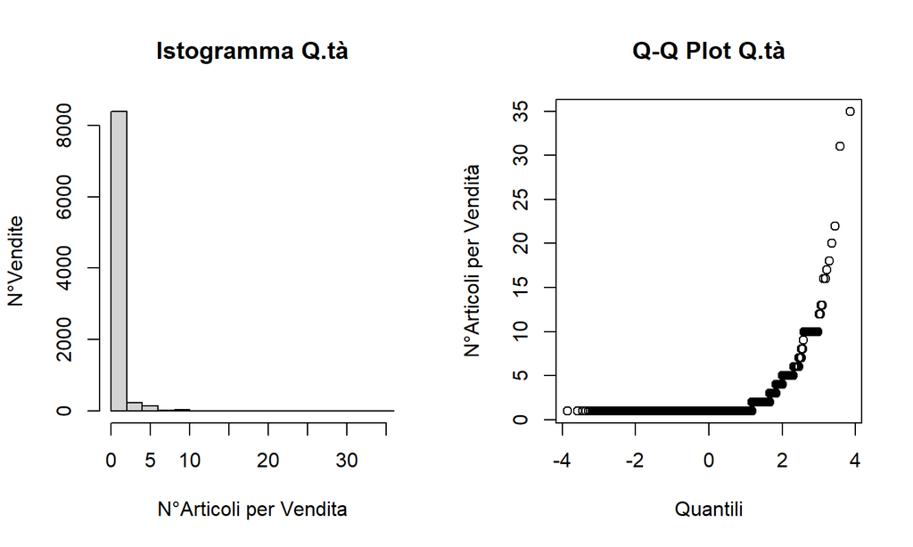

## Istogramma e QQplot Importo

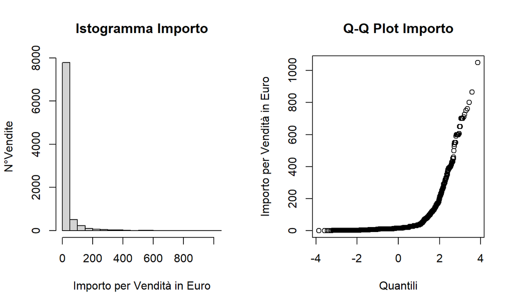

Sia gli istogramma di frequenza, sia i QQ-plot mostrano che le variabili Q.tà e Importo non assumono le determinazioni di una normale.

## Analisi descrittiva bivariata

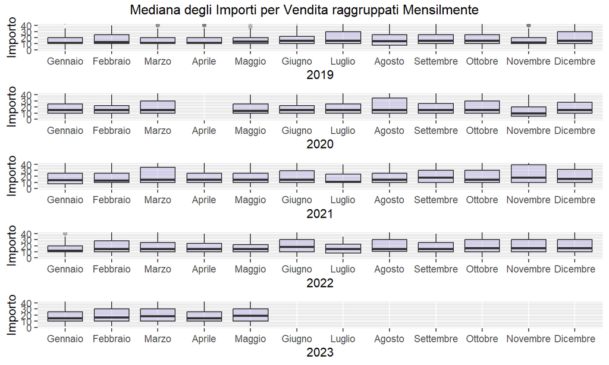

## Columnplot diviso per anni

[figure not shown]

Per una comparazione degli Importi mensili nei vari anni è stato realizzato un grafico a barre

## areaplot totale per Q.tà

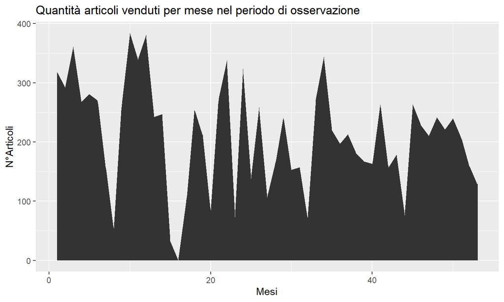

## areaplot totale per Importo

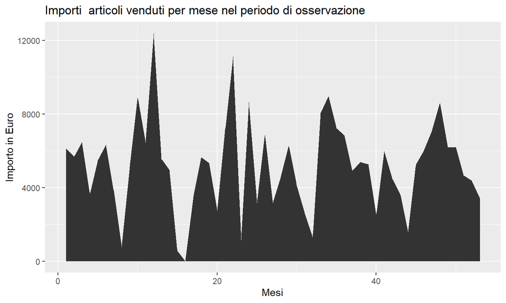

In entrambi i grafici si evidenzia una andamento non lineare; essendo i dati a cadenza mensile, in essi è presente il fenomeno denominato stagionalità.

## Andamenti tipici delle serie storiche

Dai grafici deduciamo che le serie storiche possono avere diversi pattern.

- Pattern stagionale: fluttuazioni dovute al particolare periodo dell’anno.
- Pattern ciclico: movimenti ricorrenti di lunga durata.
- Trend o tendenza di fondo.

## Confronto Q.tà Libri/Strumenti

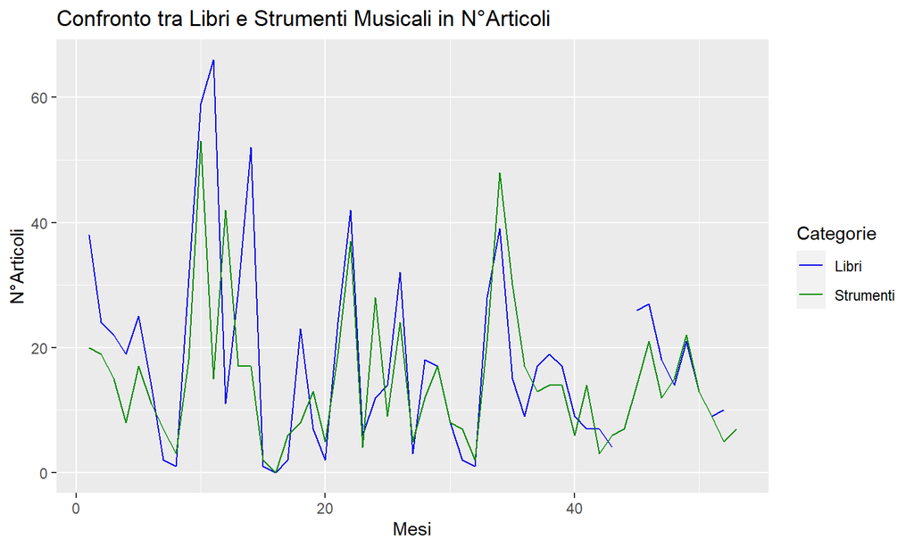

Le due serie hanno un andamento quasi sovrapponibile.

## Cosnfronto Q.tà Accessori//Strumenti

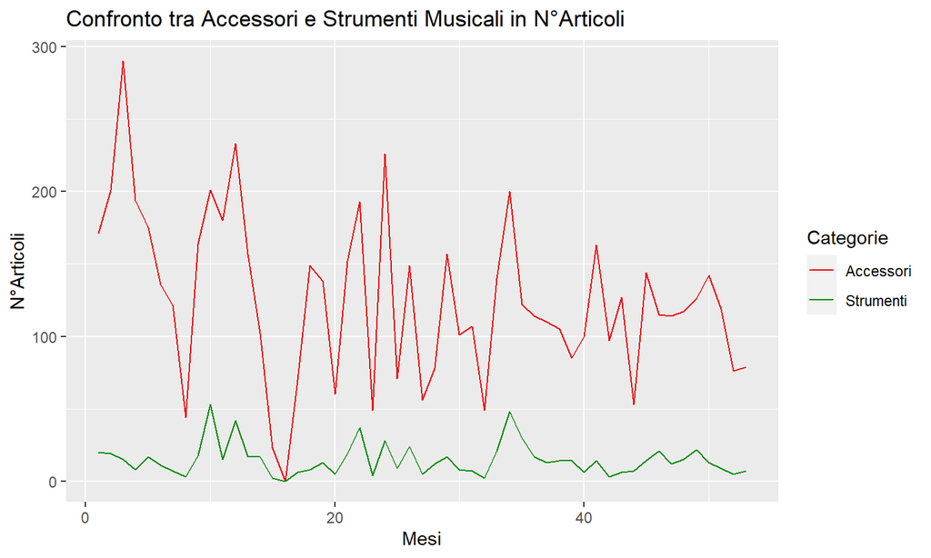

## Confronto Q.tà Liuteria/Strumenti

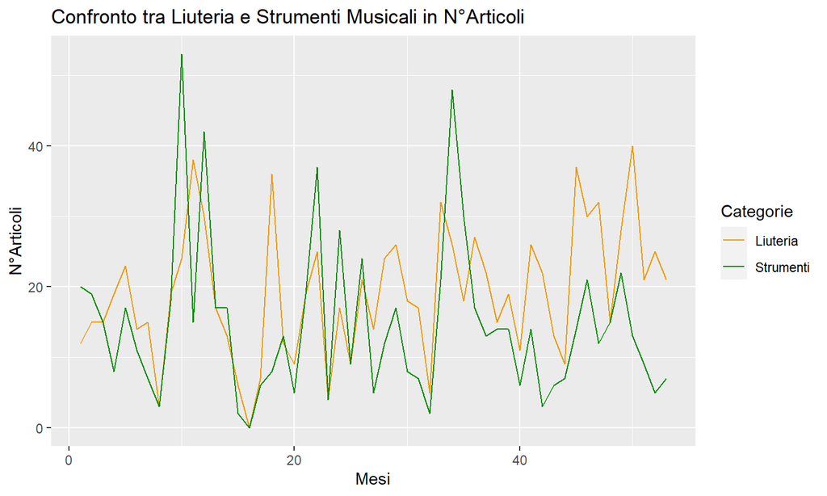

La serie Liuteria ha un pattern stagionale, ma anche un pattern ciclico.

## Confronto Q.tà 5 Categorie

Analizzo ora le 5 voci della variabile Categoria:

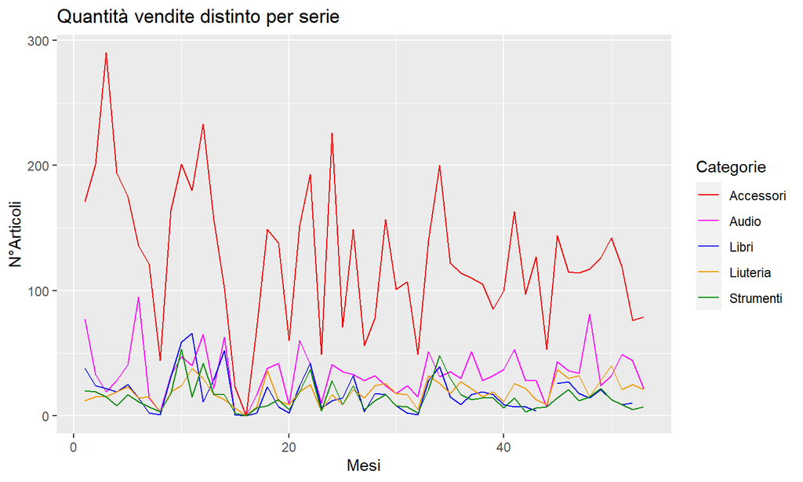

## Confronto Importo 5 Categorie

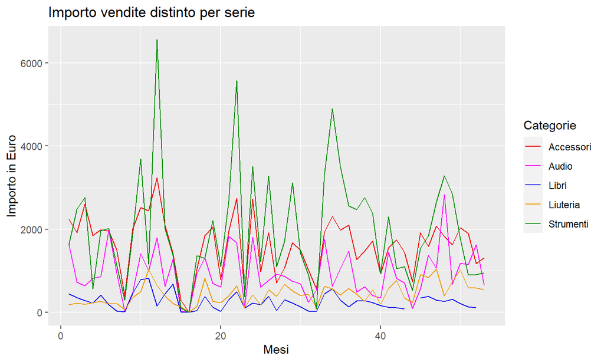

## Confornto Importo per Anno

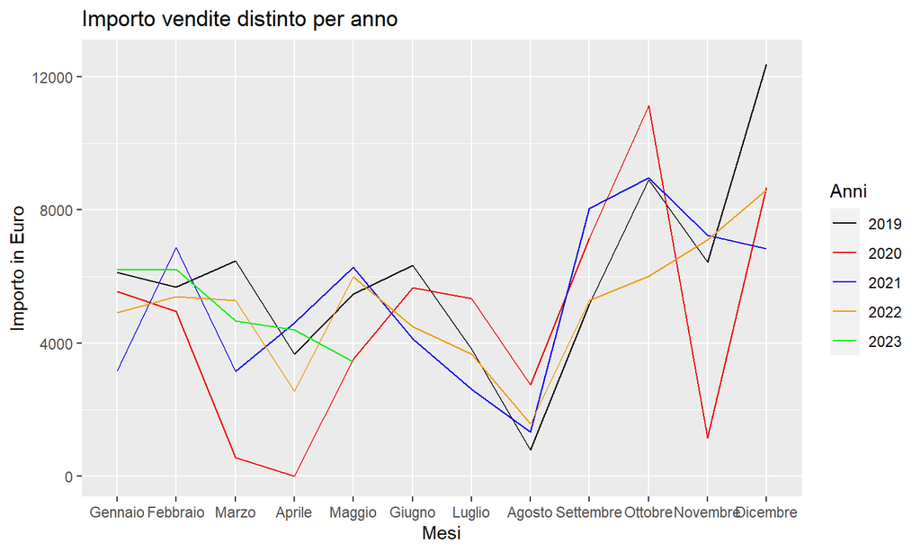

## Conclusioni

La mia analisi ha evidenziato che serie storiche delle variabili Q.tà e Fatturato presentano una combinazione di diversi pattern delle vendite.

La serie Liuteria è un esempio di pattern ciclico. Si vede che l’ampiezza delle oscillazioni cicliche è generalmente più grande di quella dovuta alla stagionalità.

Grazie dell’attenzione.